# 2024 NH3-loss Statistical Models, outdoor only - sqrt

Maarit Mäenpää + NJH

2025-10-27

## Model A_base

To reduce the number of parameters in the statistical model, we categorised different fertilisers into categories consisting of;

**Urea**: Fertilisers where the main component was urea

**UAN**: UAN

**ammonium+1**: Fertilisers including a low percentage of ammonium

**ammonium+2**: Fertilisers with higher percentage of ammonium

The table below depicts the categorisation of fertilisers, and the number of observations in each sub-category.

```
## # A tibble: 10 × 3
##    FertiliserType count mean_emm
##    <fct>          <int>    <dbl>
##  1 ABC                6     5.5
##  2 AN               115     2.97
##  3 AS               109    12.6
##  4 CAN               76     2.01
##  5 DAP               13     8.12
##  6 UAN               99     8.83
##  7 UAS               16    18.6
##  8 UP                 9    13.7
##  9 urea             800    15.3
## 10 UUP                6    12.7
```

```
##   Fertiliser   N
## 1      urea+ 964
## 2        UAN 108
## 3 ammonium+1 141
## 4 ammonium+2 198
```

In Model A_base, we examined the effects of application method (Application) and measurement method (Method) on NH3 emissions. The tables below show the number of observations within each category examined.

```
##    Application    N
## 1    Broadcast 1031
## 2 Incorporated  148
## 3     Injected   14
## 4       Liquid  218
```

```
##                Method   N
## 1            Micromet 205
## 2                 15N   5
## 3      Closed chamber 369
## 4         Drager-Tube 161
## 5           Semi-open 148
## 6 Ventilated chambers 259
## 7          Windtunnel 264
```

Table below shows counts of all categories of variables:

```
## , ,  = Micromet
##
##
##              Broadcast Incorporated Injected Liquid
##   urea+            128            5        0     16
##   UAN                0            0        0     31
##   ammonium+1        20            0        0      0
##   ammonium+2         0            0        0      5
##
## , ,  = 15N
##
##
##              Broadcast Incorporated Injected Liquid
##   urea+              5            0        0      0
##   UAN                0            0        0      0
##   ammonium+1         0            0        0      0
##   ammonium+2         0            0        0      0
##
## , ,  = Closed chamber
##
##
##              Broadcast Incorporated Injected Liquid
##   urea+            171           33        0     36
##   UAN                0            0        0     39
##   ammonium+1        16            3        0     10
##   ammonium+2        53            6        0      2
##
## , ,  = Drager-Tube
##
##
##              Broadcast Incorporated Injected Liquid
##   urea+             78           34        0     36
##   UAN                0            0        0      0
##   ammonium+1         4            6        0      0
##   ammonium+2         3            0        0      0
##
## , ,  = Semi-open
##
##
##              Broadcast Incorporated Injected Liquid
##   urea+             89            8        0      0
##   UAN                0            0        0      4
##   ammonium+1        21            0        0      0
##   ammonium+2        26            0        0      0
##
## , ,  = Ventilated chambers
##
##
##              Broadcast Incorporated Injected Liquid
##   urea+            127           23        0      9
##   UAN                0            0        2      6
##   ammonium+1        50            4        0      0
##   ammonium+2        37            1        0      0
##
## , ,  = Windtunnel
##
##
##              Broadcast Incorporated Injected Liquid
##   urea+            133           25        5      3
##   UAN                0            0        7     19
##   ammonium+1         6            0        0      1
##   ammonium+2        64            0        0      1
```

We used NH3-loss (%), calculated as relative difference between ammonia emissions from a test site and a control site proportional to the control, as a response variable. There were 19 negative observations out of the total 1411.

The frequency distribution of the untransformed NH3-loss measurements is shown below.

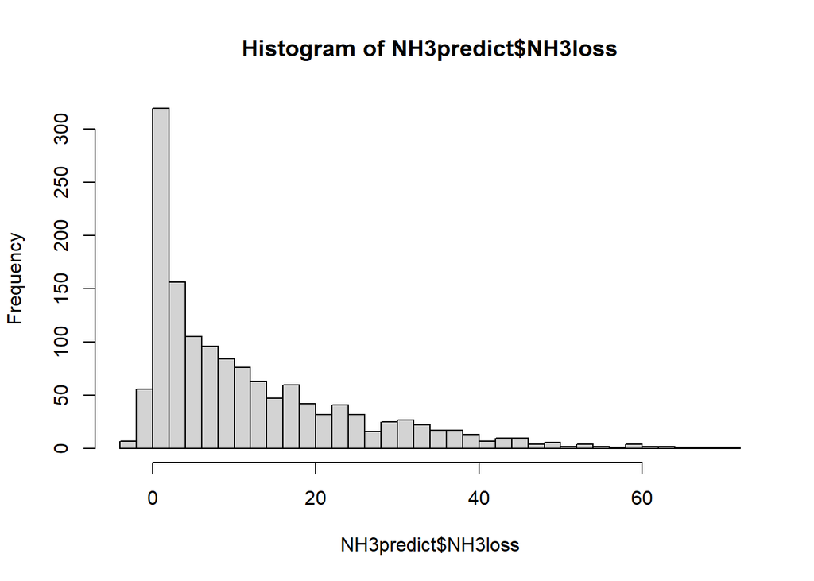

To account for non-normality, the response variable was transformed with a square root transformation. We applied a constant of 4 to allow the analysis to include negative values.

To account for heteroscedasticity, we used weighted ordinary least squares (WOLS, Olvera Astivia & Bruno 2019). We built a vector giving larger weight to observations with smaller variation. To this end, we extracted absolute residuals and fitted values from an unweighted version of Model A_Base (see below for code). We then applied a regression model between the absolute residuals (response variable and fitted values (predictor variable), to estimate the relationship between the amount of variation and the data and the model estimates. To attain a vector with higher values attached to lower variation, we used the inverse of the relationship estimated in the regression model. The weights correspond to increased weight with decrease in variation, thus giving more precedence to more accurate data.

The model assumptions are checked in the figures below:

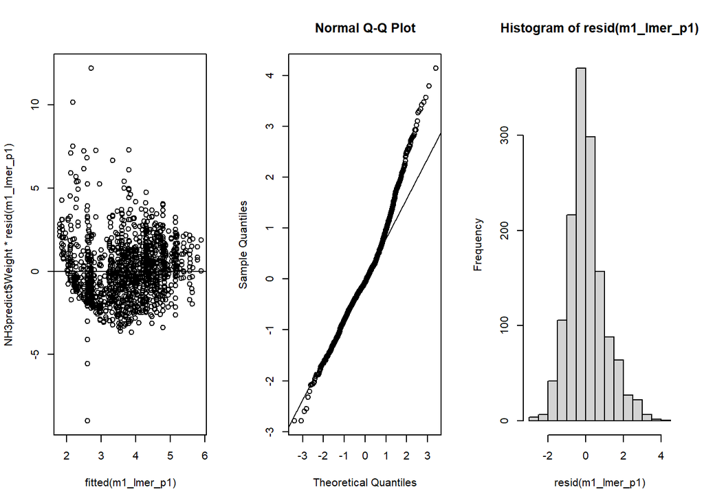

The pairwise-comparisons of factor-level effects can be seen below. The comparisons are made to urea (in Fertiliser), Broadcast (in Application) and Micromet (in Method). The estimates are given in the sqrt(x+4) -scale.

```
## Linear mixed model fit by REML. t-tests use Satterthwaite's method [
## lmerModLmerTest]
## Formula: sqrt(NH3loss + 4) ~ Fertiliser + Application + Method + (1 |      Ref)
##    Data: NH3predict
## Weights: Weight
## Control: lmerControl(optimizer = "bobyqa")
##
## REML criterion at convergence: 4073.8
##
## Scaled residuals:
##     Min      1Q  Median      3Q     Max
## -3.6565 -0.6284 -0.0839  0.5675  5.1380
##
## Random effects:
##  Groups   Name        Variance Std.Dev.
##  Ref      (Intercept) 0.7923   0.8901
##  Residual             1.7505   1.3231
## Number of obs: 1411, groups:  Ref, 165
##
## Fixed effects:
##                             Estimate Std. Error         df t value Pr(>|t|)
## (Intercept)                  4.45701    0.16681  274.68727  26.720  < 2e-16 ***
## FertiliserUAN               -0.55962    0.17345 1396.93219  -3.226  0.00128 **
## Fertiliserammonium+1        -0.85332    0.10279 1382.44170  -8.301 2.42e-16 ***
## Fertiliserammonium+2        -1.70477    0.07494 1369.83465 -22.749  < 2e-16 ***
## ApplicationIncorporated     -0.51208    0.10781 1388.51632  -4.750 2.25e-06 ***
## ApplicationInjected         -0.87772    0.27638 1386.90523  -3.176  0.00153 **
## ApplicationLiquid           -0.14754    0.16065 1230.18295  -0.918  0.35860
## Method15N                   -1.15969    0.47300 1089.44141  -2.452  0.01437 *
## MethodClosed chamber        -0.54643    0.22459  185.57874  -2.433  0.01592 *
## MethodDrager-Tube           -0.76109    0.35727  124.16424  -2.130  0.03512 *
## MethodSemi-open             -0.02248    0.26726  181.47810  -0.084  0.93307
## MethodVentilated chambers   -0.56503    0.19801  470.29581  -2.854  0.00451 **
## MethodWindtunnel             0.21651    0.26750  213.77631   0.809  0.41920
## ---
## Signif. codes:  0 '***' 0.001 '**' 0.01 '*' 0.05 '.' 0.1 ' ' 1
```

The effect sizes (marginal means) for each category of each factor are presented below, parametrised to urea (in Fertiliser), Broadcast (in Application), and Micromet (in Method). The effect sizes are given at the back-transformed scale (NH3-loss %).

```
##         Factor               Level    Effect       SE        df  lower.CL
## 1   Fertiliser               urea+ 15.864964 1.491243  379.4023 13.041026
## 2   Fertiliser                 UAN 11.189673 1.875392 1116.2850  7.732834
## 3   Fertiliser          ammonium+1  8.986615 1.365461  606.0195  6.443437
## 4   Fertiliser          ammonium+2  3.574817 0.992491  521.9416  1.750517
## 5  Application           Broadcast 15.864964 1.491243  379.4023 13.041026
## 6  Application        Incorporated 11.562491 1.536170  641.9611  8.692142
## 7  Application            Injected  8.811371 2.291707 2991.6832  4.711903
## 8  Application              Liquid 14.571588 1.904695  715.7725 11.020369
## 9       Method            Micromet 15.864964 1.491243  379.4023 13.041026
## 10      Method                 15N  6.872332 2.926488 5206.4601  1.892036
## 11      Method      Closed chamber 11.292659 1.221892  208.1167  8.978647
## 12      Method         Drager-Tube  9.659814 2.355395  125.2303  5.395976
## 13      Method           Semi-open 15.665110 1.875175  201.6114 12.141441
## 14      Method Ventilated chambers 11.147565 1.221046  318.9769  8.840492
```

[output cut: 17 more lines]

The same effect sizes (and their 95% confidence interval) are shown below:

```
## `height` was translated to `width`.
```

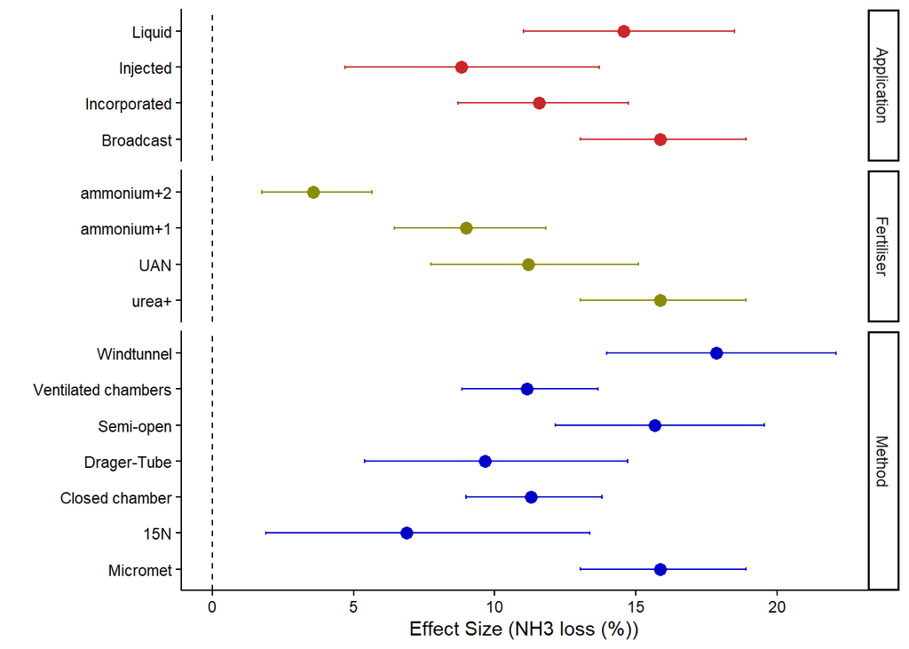

Model A_Base explains 42.09 % of the variation in the data (conditional R2), with the fixed effects explaining 15.88 % (marginal R2). The R2-values for linear mixed effects model were calculated according to Nagakawa & Schielzeth (2013).

## Model A_Application rate

In model A_Application rate, as in all models following, we applied a linear model using fitted values from Model A_Base as an offset variable, to account for the variation explained by the factors already estimated in Model 1. As in Model A_Base, we transformed the response variable (NH3-loss %) with a squareroot-transformation with a constant of 4. The model was also weighted the analysis with the same weights as Model A_Base to account for heteroscedasticity. This same structure was used in all following models.

The sole explanatory variable in model A_Application rate was application rate (kg/ha).

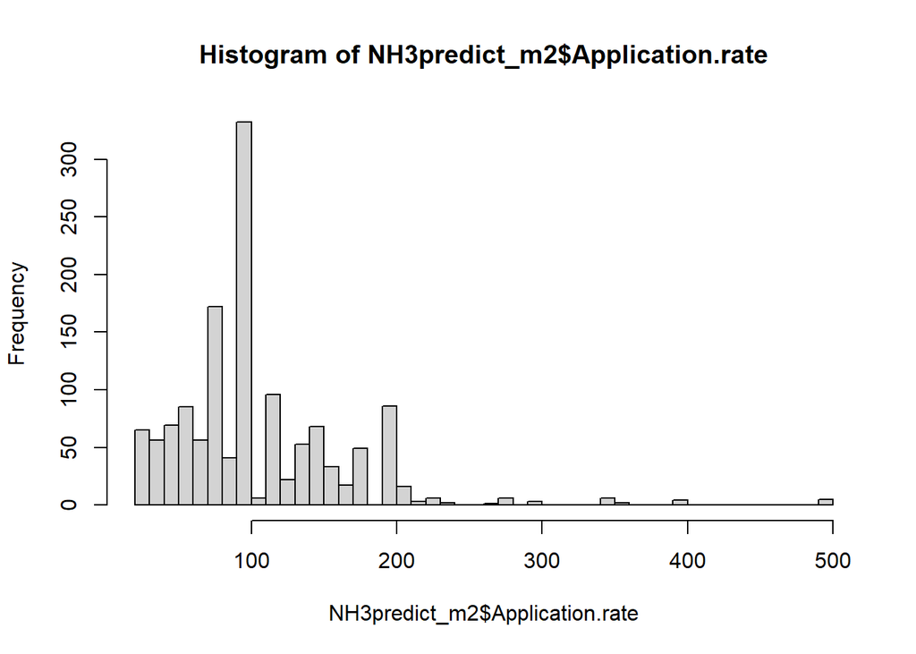

The model as it was applied can be seen below:

```r
# Model A_Application rate
m2_lm <- lm(sqrt(NH3loss+4) ~ Application.rate + offset(M1_fit),
            weights=Weight,
            data=NH3predict_m2)
```

The model assumptions can be seen below:

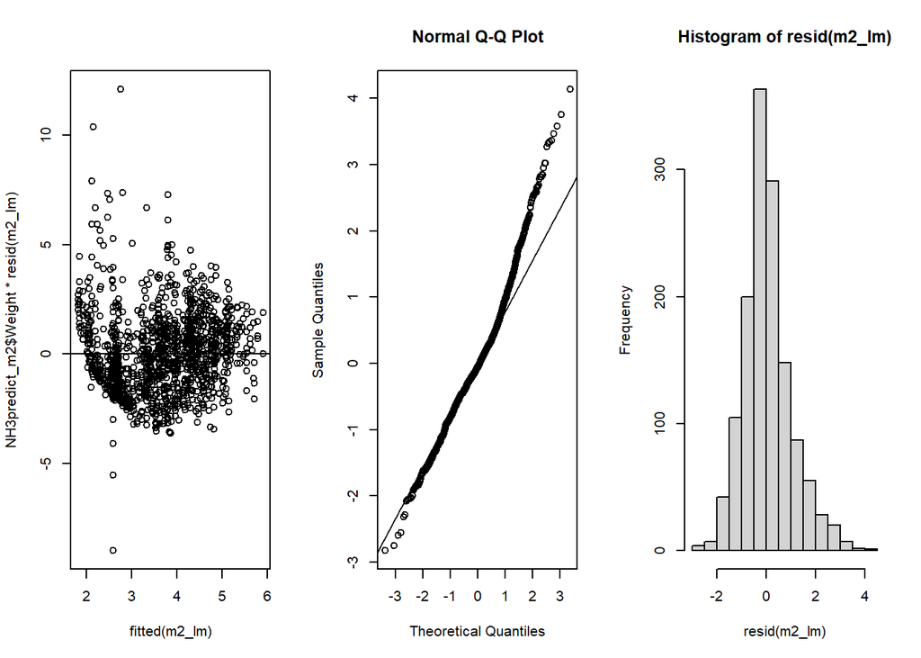

Full model output can be seen below:

```
##
## Call:
## lm(formula = sqrt(NH3loss + 4) ~ Application.rate + offset(M1_fit),
##     data = NH3predict_m2, weights = Weight)
##
## Weighted Residuals:
##     Min      1Q  Median      3Q     Max
## -4.8267 -0.8378 -0.0919  0.7300  6.7310
##
## Coefficients:
##                    Estimate Std. Error t value Pr(>|t|)
## (Intercept)      -0.0924638  0.0462998  -1.997   0.0460 *
## Application.rate  0.0008648  0.0003866   2.237   0.0254 *
## ---
## Signif. codes:  0 '***' 0.001 '**' 0.01 '*' 0.05 '.' 0.1 ' ' 1
##
## Residual standard error: 1.263 on 1358 degrees of freedom
## Multiple R-squared:  0.003672,   Adjusted R-squared:  0.002938
## F-statistic: 5.005 on 1 and 1358 DF,  p-value: 0.02544
```

Application rate explains 0.29 % of residual variation in NH3-emissions (adjusted R-squared). (Note: Adjusted R-squared is manually adjusted to incorporate the offset-variable, and thus not consistent with the adjusted R-squared from the above model output.)

Figure below is a linear approximation of the effect of Application rate on NH3-emissions (linear slope back-transformed from the square-root scale).

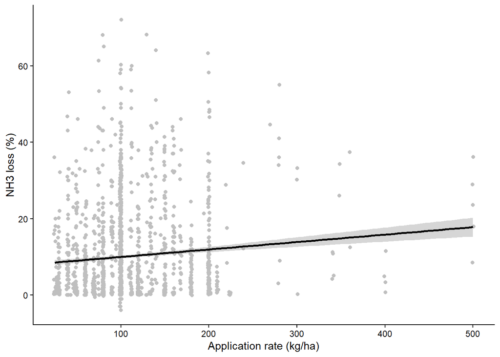

## Model A_Soil pH

Soil pH was binarised into categories, where soils with pH>7.0 were categorised as chalky, and ph<=7.0 as normal. The number of observations in each group and their frequency distribution can be seen below.

```
##   pH_cat   N
## 1 normal 858
## 2 chalky 497
```

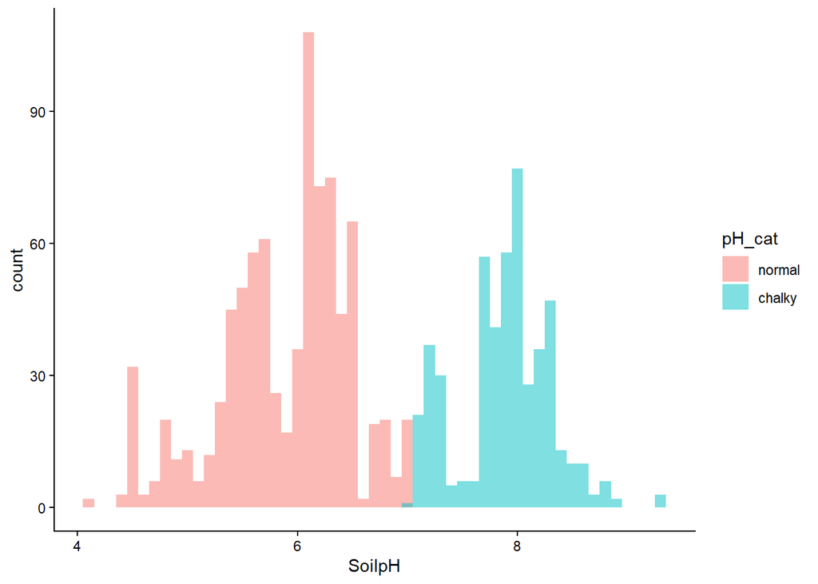

Model A_Soil pH followed the structure of Model A_Application. We added Soil pH, Fertiliser type, and the interaction between the two as fixed factors. In this model, Fertiliser types were used to identify differences between pH-categories, not to analyse the effect of Fertiliser on its own - the offset of Model A_Base removes the variation explained by Fertilisers otherwise.

```r
# Model
m3_lm <- lm(sqrt(NH3loss+4) ~ Fertiliser * pH_cat + offset(M1_fit),
            weights=Weight,
            data=NH3predict_m3)
```

The heteroscedasticity and normality of errors were as below:

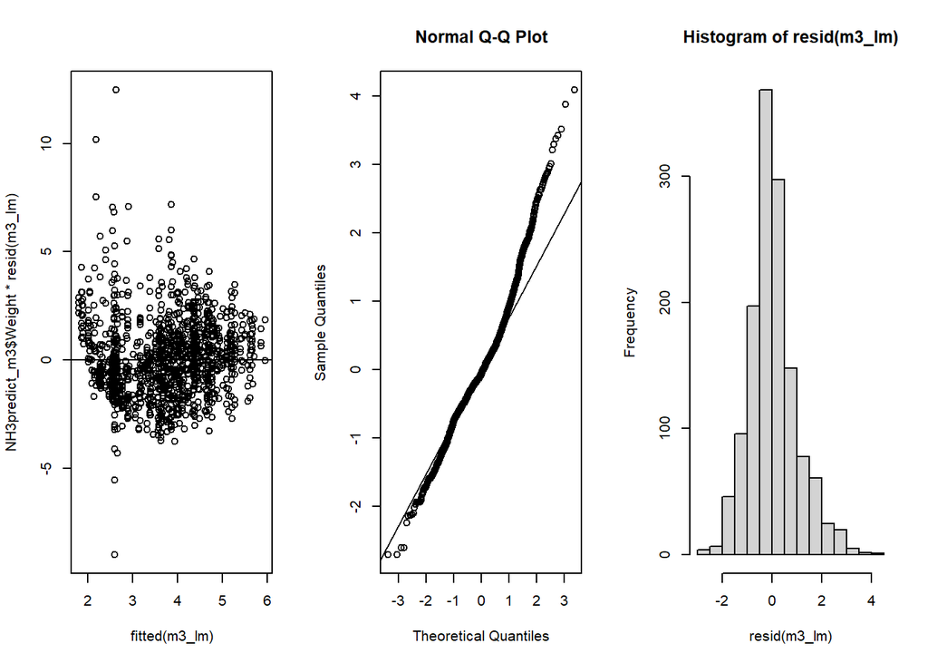

Full anova-table can be seen below:

```
## Analysis of Variance Table
##
## Response: sqrt(NH3loss + 4)
##                     Df  Sum Sq Mean Sq F value    Pr(>F)
## Fertiliser           3    0.06  0.0192  0.0123    0.9981
## pH_cat               1    1.11  1.1134  0.7160    0.3976
## Fertiliser:pH_cat    3   72.97 24.3223 15.6406 5.296e-10 ***
## Residuals         1347 2094.69  1.5551
## ---
## Signif. codes:  0 '***' 0.001 '**' 0.01 '*' 0.05 '.' 0.1 ' ' 1
```

Full model output can be seen below:

```
##
## Call:
## lm(formula = sqrt(NH3loss + 4) ~ Fertiliser * pH_cat + offset(M1_fit),
##     data = NH3predict_m3, weights = Weight)
##
## Weighted Residuals:
##     Min      1Q  Median      3Q     Max
## -4.8306 -0.7807 -0.1026  0.7381  6.9449
##
## Coefficients:
##                                   Estimate Std. Error t value Pr(>|t|)
## (Intercept)                        0.05339    0.03823   1.397   0.1628
## FertiliserUAN                     -0.12832    0.10217  -1.256   0.2093
## Fertiliserammonium+1              -0.46862    0.10370  -4.519 6.75e-06 ***
## Fertiliserammonium+2              -0.05725    0.05989  -0.956   0.3394
## pH_catchalky                      -0.13539    0.05853  -2.313   0.0209 *
## FertiliserUAN:pH_catchalky         0.40346    0.18618   2.167   0.0304 *
## Fertiliserammonium+1:pH_catchalky  1.02617    0.15294   6.710 2.86e-11 ***
## Fertiliserammonium+2:pH_catchalky  0.19151    0.12860   1.489   0.1367
## ---
## Signif. codes:  0 '***' 0.001 '**' 0.01 '*' 0.05 '.' 0.1 ' ' 1
##
## Residual standard error: 1.247 on 1347 degrees of freedom
## Multiple R-squared:  0.03418,    Adjusted R-squared:  0.02916
## F-statistic: 6.811 on 7 and 1347 DF,  p-value: 5.742e-08
```

The model explained 2.84 % of the residual variation in NH3-loss.

### Combining A_Base and A_Soil pH

For acquiring estimates for Soil pH in different fertiliser types at the same time, and same scale as the base-model, we added Soil pH and the interaction between pH and FertiliserType into the initial model. Please note this model has less data than Model A_Base, and as it includes new parameters, the estimates change slightly.

The effect sizes (marginal means) for the interaction can be seen below. The effect sizes are given at the back-transformed scale (NH3-loss %), parametrised to Fertiliser=urea+, Application=Broadcast, Method=Micromet, pH=normal.

```
##                Factor               Level    Effect       SE        df
## 1          Fertiliser               urea+ 15.541107 1.577229  377.7758
## 2          Fertiliser                 UAN  8.328997 1.961244 1310.8897
## 3          Fertiliser          ammonium+1  3.986176 1.225413  773.5242
## 4          Fertiliser          ammonium+2  2.967226 1.007987  507.4514
## 5         Application           Broadcast 15.541107 1.577229  377.7758
## 6         Application        Incorporated 10.977436 1.578073  610.0163
## 7         Application            Injected 10.081163 2.526309 2646.1649
## 8         Application              Liquid 15.284682 2.016273  672.6392
## 9              Method            Micromet 15.541107 1.577229  377.7758
## 10             Method                 15N  6.591105 2.837578 4809.7763
## 11             Method      Closed chamber 11.254636 1.255047  216.3887
## 12             Method         Drager-Tube  9.556784 2.378294  133.3877
## 13             Method           Semi-open 16.412046 1.876236  192.6491
## 14             Method Ventilated chambers 11.298695 1.281372  314.9225
```

[output cut: 37 more lines]

The same effect sizes (and their 95% confidence interval) are shown below:

```
## `height` was translated to `width`.
```

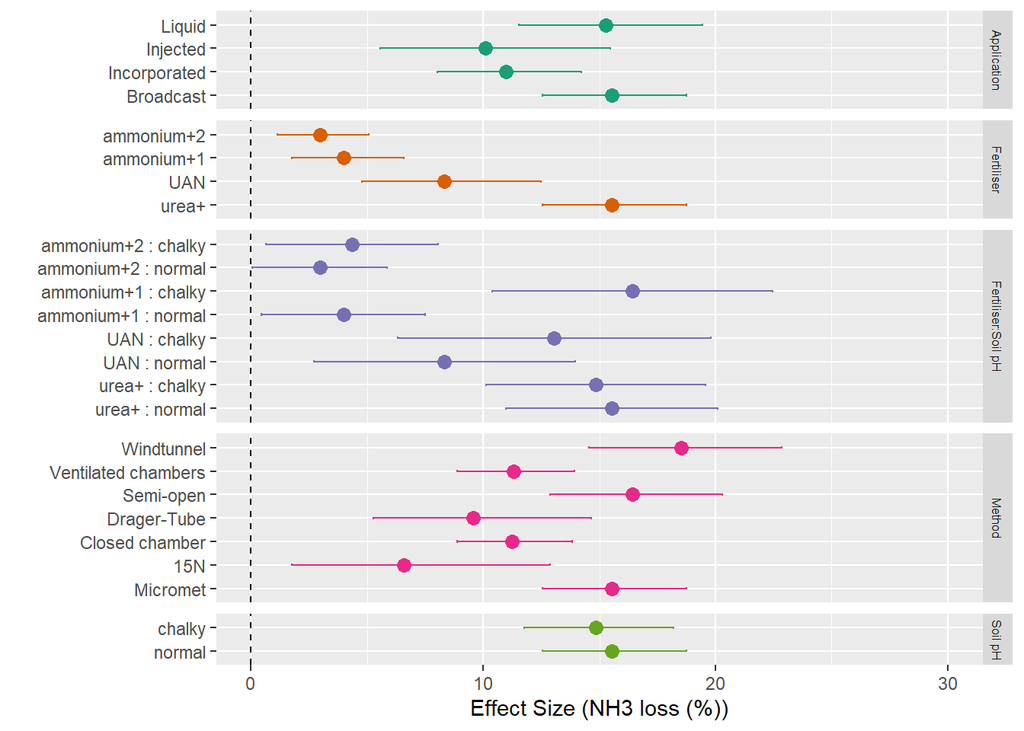

## Model A_Soil clay content

In Model A_Soil clay content, we explored the effect of Soil clay content (%) on NH3-loss (%).

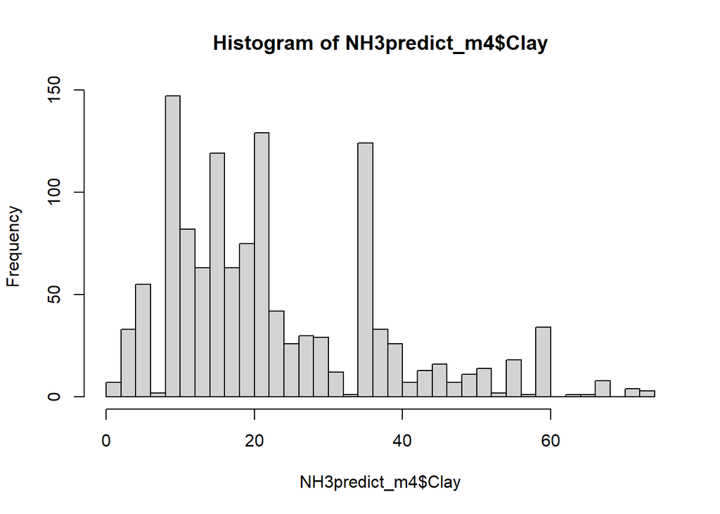

We used Soil clay content (%) as a continuous covariate and the sole explanatory variable in the model.

```r
# Model
m4_lm <- lm(sqrt(NH3loss +4) ~ Clay + offset(M1_fit),
            weights=Weight,
            data=NH3predict_m4)
```

The model assumptions (heteroscedasticity and normality of errors):

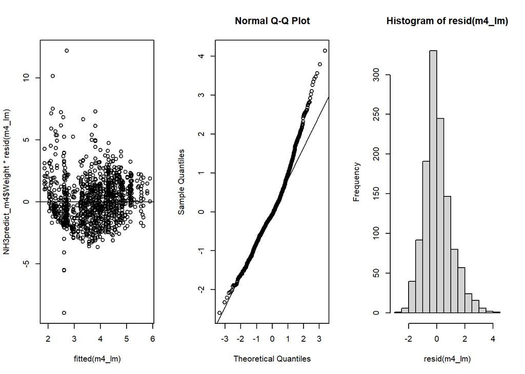

Full model output can be seen below:

```
##
## Call:
## lm(formula = sqrt(NH3loss + 4) ~ Clay + offset(M1_fit), data = NH3predict_m4,
##     weights = Weight)
##
## Weighted Residuals:
##     Min      1Q  Median      3Q     Max
## -4.8358 -0.8308 -0.1172  0.7704  6.7951
##
## Coefficients:
##              Estimate Std. Error t value Pr(>|t|)
## (Intercept) -0.002069   0.043404  -0.048    0.962
## Clay         0.000102   0.001625   0.063    0.950
##
## Residual standard error: 1.254 on 1236 degrees of freedom
## Multiple R-squared:  3.188e-06,  Adjusted R-squared:  -0.0008059
## F-statistic: 0.00394 on 1 and 1236 DF,  p-value: 0.95
```

Figure below is a linear approximation of the effect of Soil Clay content (%) on NH3-emissions (linear slope back-transformed from the square-root scale).

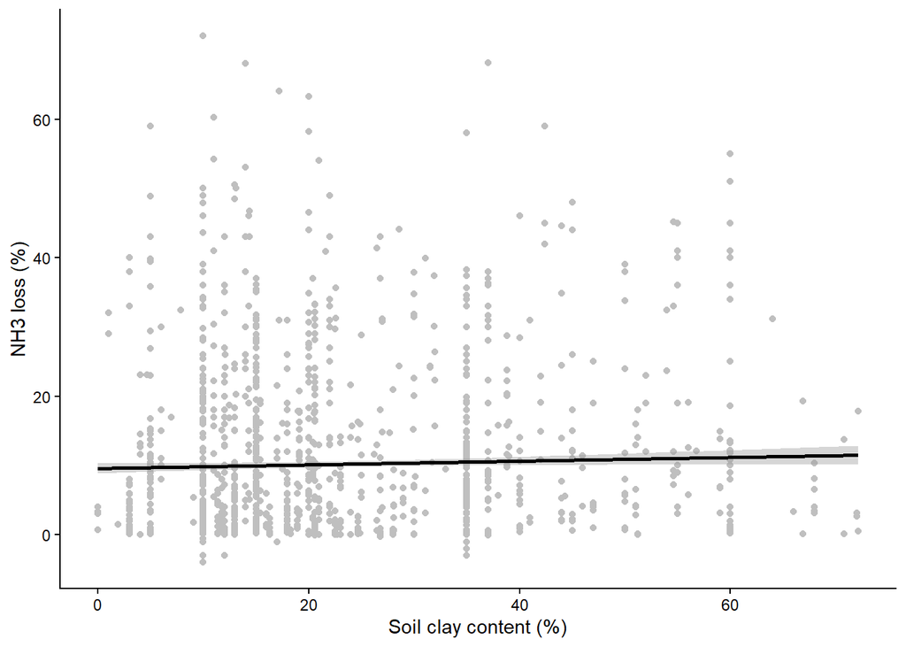

Test to see if a exponential function provides a better fit for the Clay data. The fit and parameters c and d were fitted a non-linear least-squares model.

```
##
## Formula: NH3loss ~ c * exp(d * (Clay))
##
## Parameters:
##    Estimate Std. Error t value Pr(>|t|)
## c 11.133857   0.637194  17.473   <2e-16 ***
## d  0.002998   0.001988   1.508    0.132
## ---
## Signif. codes:  0 '***' 0.001 '**' 0.01 '*' 0.05 '.' 0.1 ' ' 1
##
## Residual standard error: 12.79 on 1236 degrees of freedom
##
## Number of iterations to convergence: 15
## Achieved convergence tolerance: 1.49e-08
```

The fitted relationship is as below:

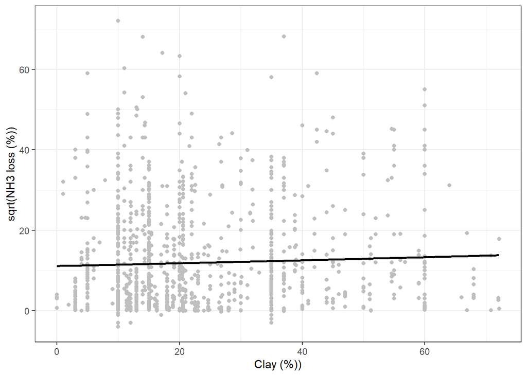

```r
# Transforming the Clay values to exp-scale
NH3predict_m4$Clay.exp <- coef(MR_nls_clay)[[1]]*exp(coef(MR_nls_clay)[[2]]*NH3predict_m4$Clay)
```

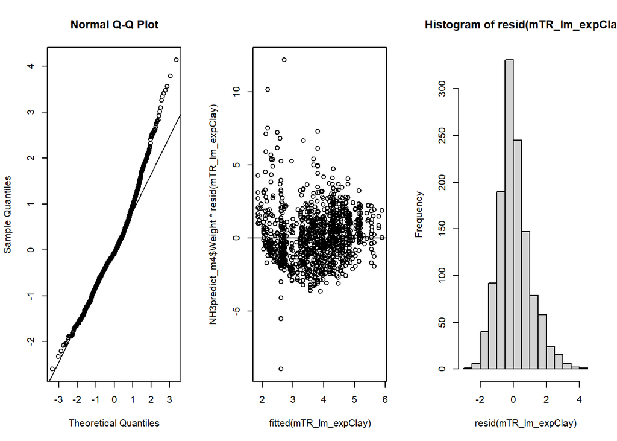

```
##
## Call:
## lm(formula = sqrt(NH3loss + 4) ~ Clay.exp + offset(M1_fit), data = NH3predict_m4,
##     weights = Weight)
##
## Weighted Residuals:
##     Min      1Q  Median      3Q     Max
## -4.8349 -0.8307 -0.1172  0.7713  6.7943
##
## Coefficients:
##              Estimate Std. Error t value Pr(>|t|)
## (Intercept) -0.047382   0.528367   -0.09    0.929
## Clay.exp     0.003993   0.044266    0.09    0.928
##
## Residual standard error: 1.254 on 1236 degrees of freedom
## Multiple R-squared:  6.584e-06,  Adjusted R-squared:  -0.0008025
## F-statistic: 0.008137 on 1 and 1236 DF,  p-value: 0.9281
```

## Model A_Soil organic carbon

Soil organic carbon (g/kg) was modeled as a continuous variable. Most soils in the data were mineral (with a cutoff of 120 g/kg SOC), with only 3 organic soils in the dataset.

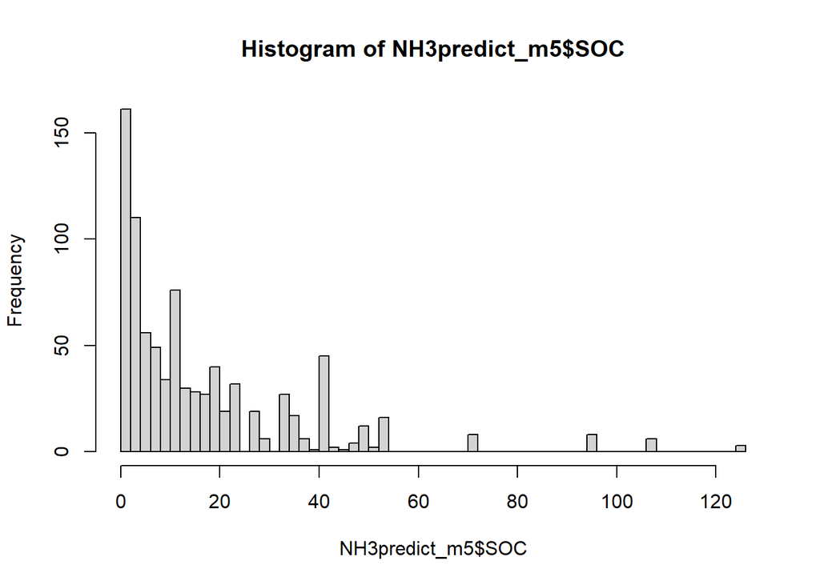

We used Soil organic carbon (g/kg) as a sole continuous covariate in the model.

```r
# Model
m5_lm <- lm(sqrt(NH3loss+4) ~ SOC + offset(M1_fit),
            weights=Weight,
            data=NH3predict_m5)
```

The model assumptions (heteroscedasticity and normality of errors):

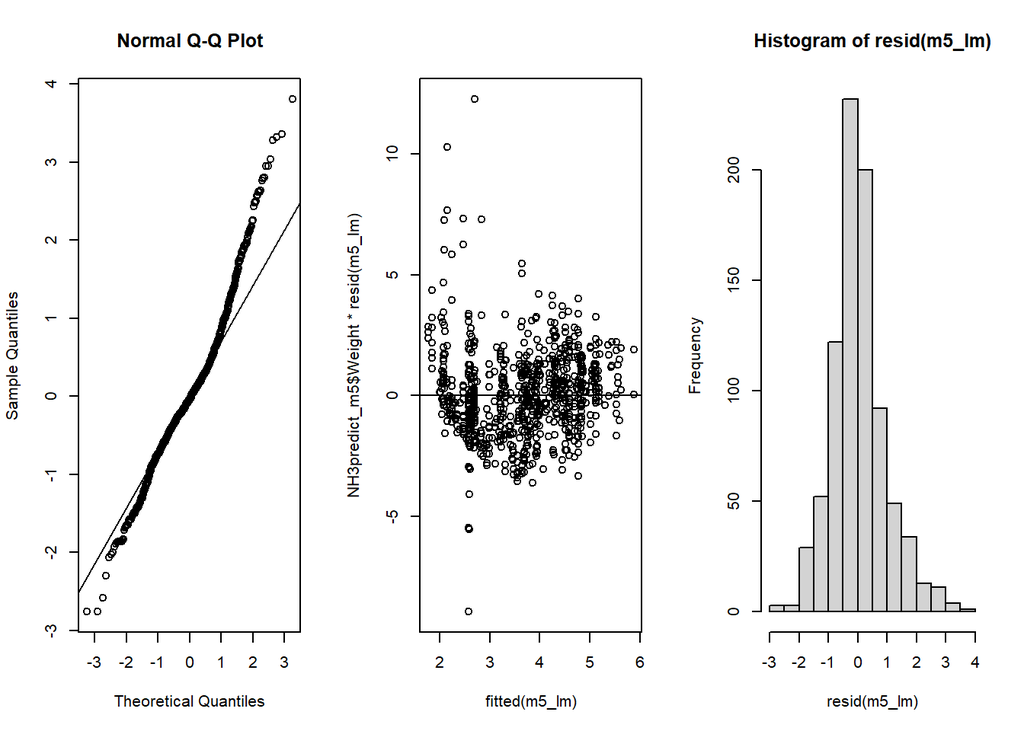

There was no effect of Soil organic carbon (g/kg) on NH3 loss (F(1, 843) =0.11, p = 0.743).

Full model output can be seen below:

```
##
## Call:
## lm(formula = sqrt(NH3loss + 4) ~ SOC + offset(M1_fit), data = NH3predict_m5,
##     weights = Weight)
##
## Weighted Residuals:
##     Min      1Q  Median      3Q     Max
## -4.8111 -0.7525 -0.0591  0.6788  6.8282
##
## Coefficients:
##              Estimate Std. Error t value Pr(>|t|)
## (Intercept) -0.026069   0.033838  -0.770    0.441
## SOC          0.000419   0.001278   0.328    0.743
##
## Residual standard error: 1.21 on 843 degrees of freedom
## Multiple R-squared:  0.0001274,  Adjusted R-squared:  -0.001059
## F-statistic: 0.1074 on 1 and 843 DF,  p-value: 0.7432
```

Adjusted R2-value of the model was -0.001, and multiple R2 was 1.27^{-4}. The negative adjusted R2-value indicates that the amount of variation accounted for by Soil organic carbon is negligible. In practice, soil organic carbon explains no variation in the data.

Figure below is a linear approximation of the effect of Soil organic carbon (g/kg) on NH3-emissions (linear slope back-transformed from the square-root scale).

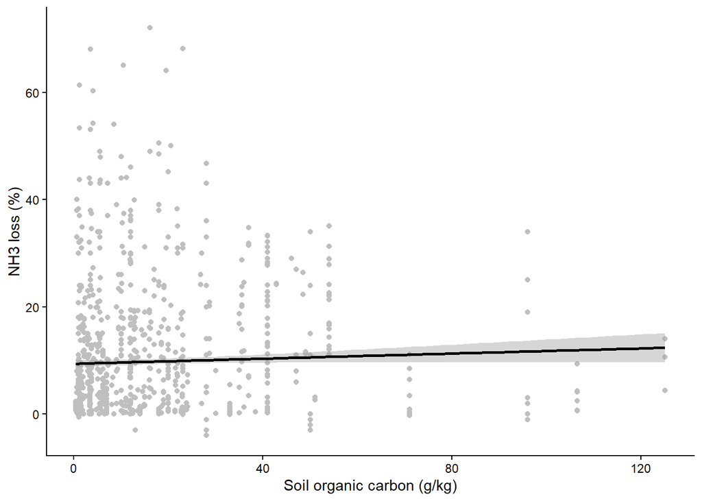

## Model A_Cover

```
##    Cover   N
## 1   None 360
## 2 Arable 713
## 3  Grass 320
## 4  Other  18
```

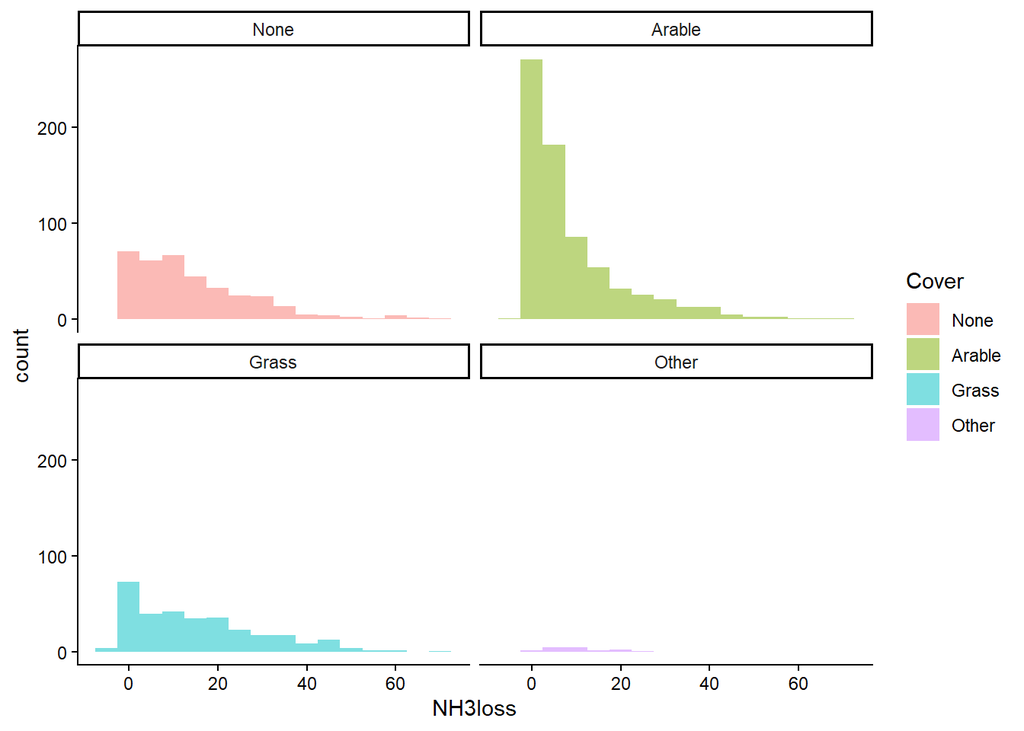

We added Cover as a fixed factor and a sole explanatory variable in the model.

```r
# Model
m6_lm <- lm(sqrt(NH3loss+4) ~ Cover + offset(M1_fit),
            weights=Weight,
            data=NH3predict_m6)
```

The model assumptions (heteroscedasticity and normality of errors):

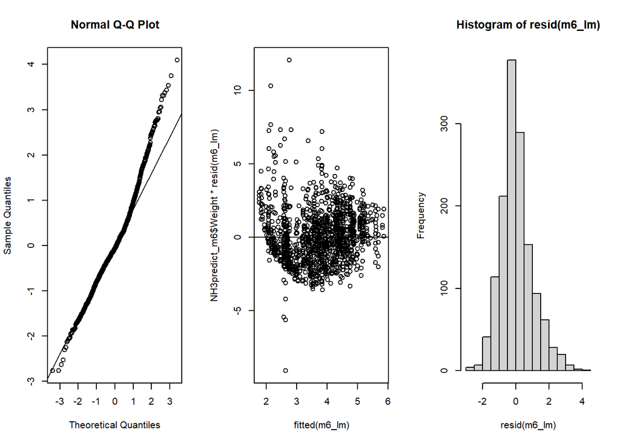

The cover categories (none, arable, grass) did not significantly differ from one another in NH3-emissions (F(3, 1407) =0.71, p = 0.546).

Full model output can be seen below:

```
##
## Call:
## lm(formula = sqrt(NH3loss + 4) ~ Cover + offset(M1_fit), data = NH3predict_m6,
##     weights = Weight)
##
## Weighted Residuals:
##     Min      1Q  Median      3Q     Max
## -4.8973 -0.8379 -0.1070  0.7584  6.7193
##
## Coefficients:
##             Estimate Std. Error t value Pr(>|t|)
## (Intercept)  0.04379    0.04769   0.918    0.359
## CoverArable -0.06761    0.05532  -1.222    0.222
## CoverGrass  -0.01176    0.06890  -0.171    0.864
## CoverOther  -0.12322    0.20963  -0.588    0.557
##
## Residual standard error: 1.26 on 1407 degrees of freedom
## Multiple R-squared:  0.001512,   Adjusted R-squared:  -0.0006166
## F-statistic: 0.7104 on 3 and 1407 DF,  p-value: 0.5458
```

Adjusted R2-value of the model was -6.2^{-4}, and multiple R2 was 0.00151. The negative adjusted R2-value indicates that the amount of variation accounted for by Cover crops is negligible. In practice, cover crops explain no variation in the data.

```
##    Cover   emmean         SE   df lower.CL upper.CL
## 1   None 3.684416 0.04768558 1407 3.590874 3.777959
## 2 Arable 3.616805 0.02803985 1407 3.561800 3.671809
## 3  Grass 3.672655 0.04973342 1407 3.575096 3.770215
## 4  Other 3.561197 0.20413577 1407 3.160754 3.961641
```

```
## `height` was translated to `width`.
```

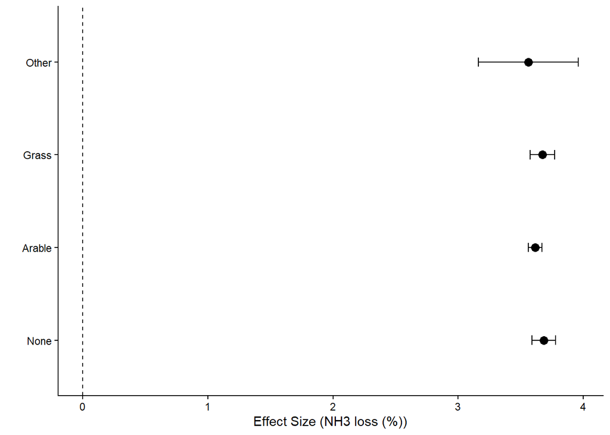

## Model A_Air temperature and rainfall

AirTemperature over the duration of the experiment (Celcius) and mean rainfall over the experimental period (mm) were analysed together, to explore interactions between the two variables. The frequency distributions of the two variables can be seen below.

There are 934 observations in the analysis.

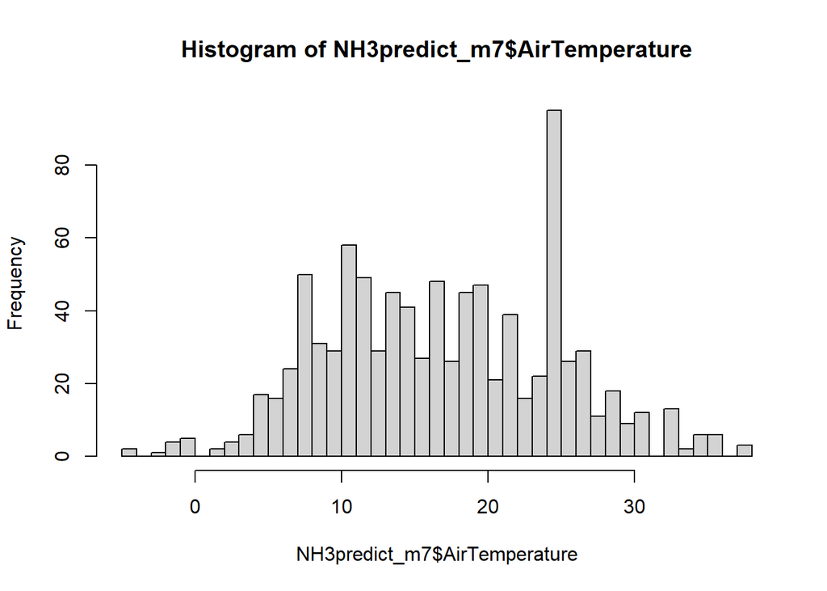

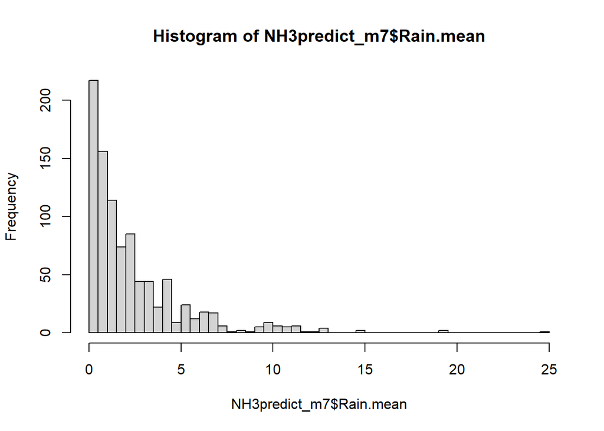

```r
# Model
mTR_lm <- lm(sqrt(NH3loss+4) ~ AirTemperature * Rain.mean + offset(M1_fit),
             weights=Weight,
             data=NH3predict_m7)
```

The model assumptions (heteroscedasticity and normality of errors):

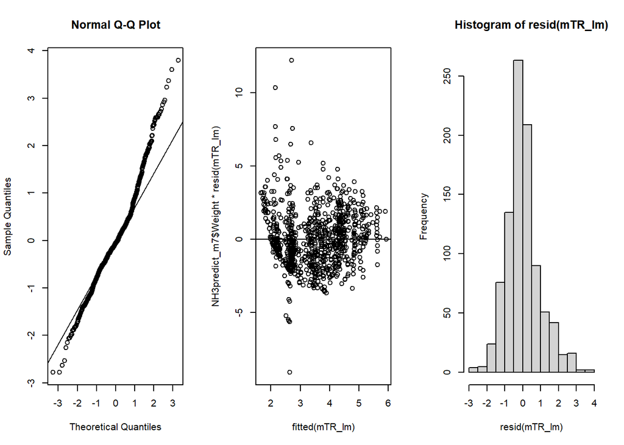

There was a marginally non-significant effect of interaction (F(1, 930) =1.46, p = 0.228), and a marginally non-significant main effect of mean rainfall (F(1, 930) =3.63, p = 0.057). There was no main effect of air temperature (F(1, 930) =3.59, p = 0.058).

Full model output can be seen below:

```
##
## Call:
## lm(formula = sqrt(NH3loss + 4) ~ AirTemperature * Rain.mean +
##     offset(M1_fit), data = NH3predict_m7, weights = Weight)
##
## Weighted Residuals:
##     Min      1Q  Median      3Q     Max
## -4.9010 -0.8226 -0.1004  0.7039  6.8085
##
## Coefficients:
##                           Estimate Std. Error t value Pr(>|t|)
## (Intercept)              -0.031759   0.082476  -0.385   0.7003
## AirTemperature            0.004816   0.004448   1.083   0.2793
## Rain.mean                -0.056011   0.032554  -1.721   0.0857 .
## AirTemperature:Rain.mean  0.001735   0.001437   1.208   0.2275
## ---
## Signif. codes:  0 '***' 0.001 '**' 0.01 '*' 0.05 '.' 0.1 ' ' 1
##
## Residual standard error: 1.265 on 930 degrees of freedom
## Multiple R-squared:  0.009254,   Adjusted R-squared:  0.006058
## F-statistic: 2.895 on 3 and 930 DF,  p-value: 0.03431
```

Air temperature and rainfall, and the interaction between the two explain 0.61 % of the variation in the data.

The marginally non-significant interaction between rainfall and temperature can be interpreted as the slope of air temperature increasing in steepness with increasing rainfall. This means that the effect of temperature is dependent on rainfall, and temperature only has an effect when rain is present.

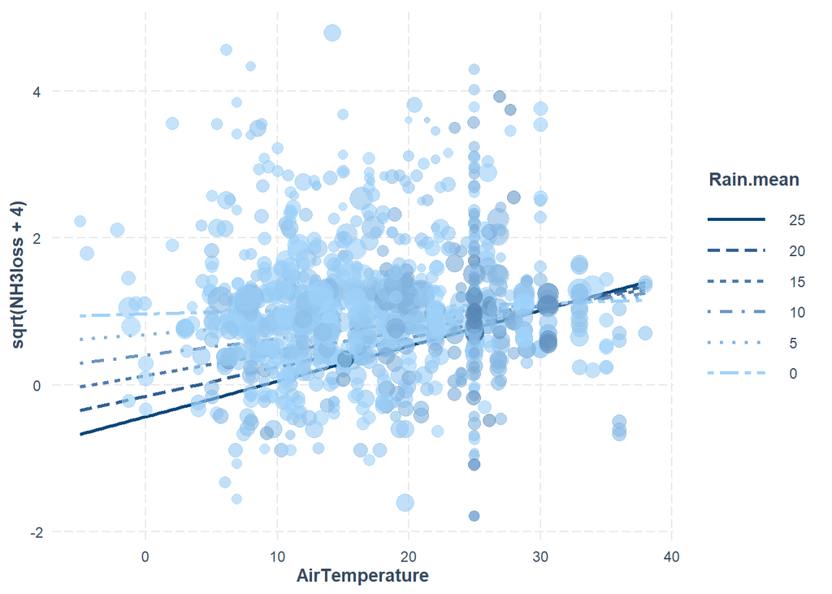

Similarly, the interaction can be interpreted from the perspective of rain: The association between rain and NH3 emissions changes from negative to slightly positive with increasing temperature.

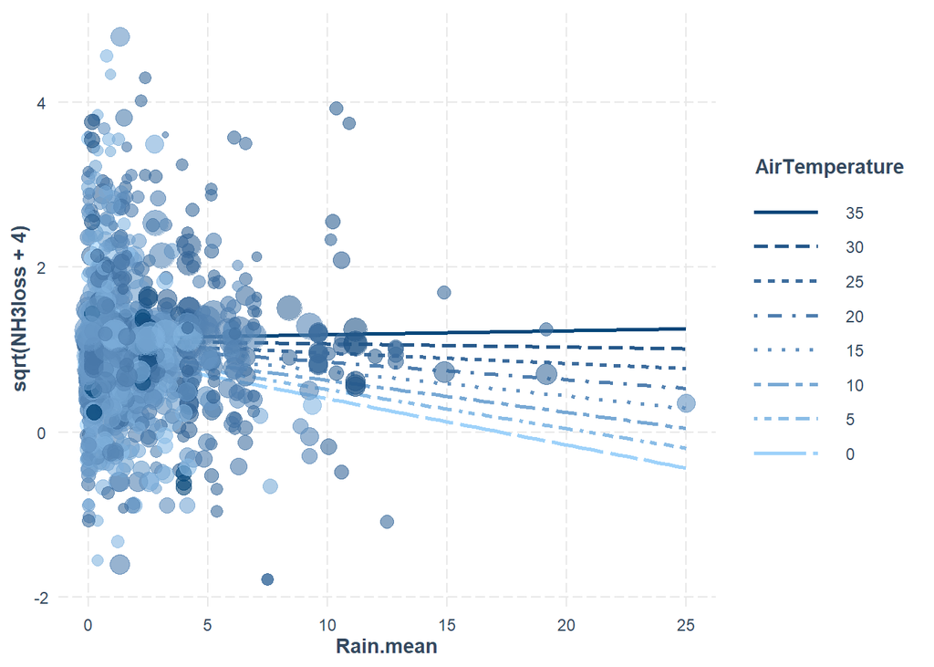

Simple slope analysis on the interaction can be seen below. The slope of temperature is statistically significant within range noted below. Note that the results below rely on statistical significance of the interaction in the model above, which is not fulfilled.

[figure not shown]

```
## JOHNSON-NEYMAN INTERVAL
##
## When Rain.mean is INSIDE the interval [1.28, 8.41], the slope of
## AirTemperature is p < .05.
##
## Note: The range of observed values of Rain.mean is [0.00, 25.00]
```

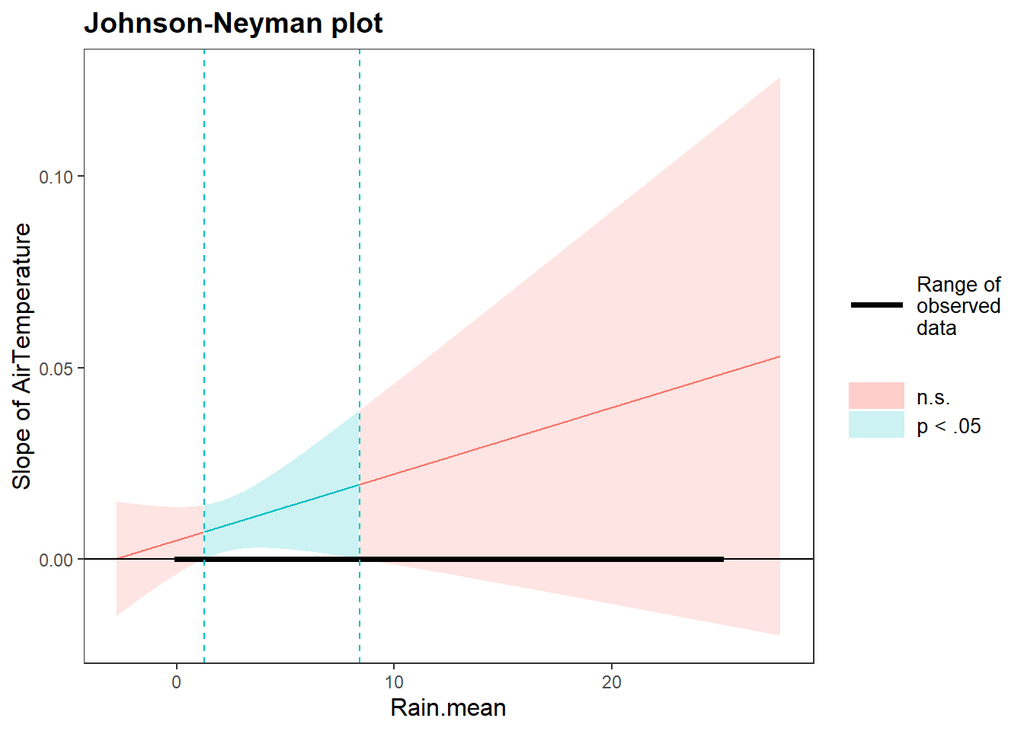

### A_Air temperature

Considering air temperature separately, there is a statistically significant effect of air temperature (F(1, 1045) =4.8, p = 0.029). Adjusted R2-value of the model was 0.00362, and multiple R2 was 0.00457. This means air temperature explains 0.362 % of the variation.

There are 1047 observations in the analysis.

The full model output with the slopes and their standard error can be seen below:

```
##
## Call:
## lm(formula = sqrt(NH3loss + 4) ~ AirTemperature + offset(M1_fit),
##     data = NH3predict_m7_2, weights = Weight)
##
## Weighted Residuals:
##     Min      1Q  Median      3Q     Max
## -4.8732 -0.8272 -0.0877  0.7193  6.8316
##
## Coefficients:
##                 Estimate Std. Error t value Pr(>|t|)
## (Intercept)    -0.116612   0.058417  -1.996   0.0462 *
## AirTemperature  0.006886   0.003142   2.191   0.0287 *
## ---
## Signif. codes:  0 '***' 0.001 '**' 0.01 '*' 0.05 '.' 0.1 ' ' 1
##
## Residual standard error: 1.241 on 1045 degrees of freedom
## Multiple R-squared:  0.004573,   Adjusted R-squared:  0.003621
## F-statistic: 4.801 on 1 and 1045 DF,  p-value: 0.02866
```

### A_Air temperature over first 7 days

There is no statistically significant effect of air temperature over the first 7 days of the experiment (F(1, 169) =1.86, p = 0.175). Adjusted R2-value of the model was 0.00502, and multiple R2 was 0.01087. This means air temperature over the first 7 days explains 0.502 % of the variation.

There are 171 observations in the analysis.

The full model output with the slopes and their standard error can be seen below:

```
##
## Call:
## lm(formula = sqrt(NH3loss + 4) ~ Temp.7d + offset(M1_fit), data = NH3predict_mA7,
##     weights = Weight)
##
## Weighted Residuals:
##     Min      1Q  Median      3Q     Max
## -4.7419 -0.7647  0.0717  1.1178  4.0952
##
## Coefficients:
##              Estimate Std. Error t value Pr(>|t|)
## (Intercept)  0.204240   0.150260   1.359    0.176
## Temp.7d     -0.012727   0.009337  -1.363    0.175
##
## Residual standard error: 1.393 on 169 degrees of freedom
## Multiple R-squared:  0.01087,    Adjusted R-squared:  0.005022
## F-statistic: 1.858 on 1 and 169 DF,  p-value: 0.1747
```

### A_Mean daily rainfall

Considering mean rainfall separately, there is no statistically significant effect of rain (F(1, 1036) =1.23, p = 0.267). Adjusted R2-value of the model was 2.2^{-4}, and multiple R2 was 0.00119. Thus, rainfall doesn’t meaningfully explain any variation in the data.

There are 1038 observations in the analysis.

The full model output with the slopes and their standard error can be seen below:

```
##
## Call:
## lm(formula = sqrt(NH3loss + 4) ~ Rain.mean + offset(M1_fit),
##     data = NH3predict_m8, weights = Weight)
##
## Weighted Residuals:
##     Min      1Q  Median      3Q     Max
## -4.8541 -0.8255 -0.1135  0.6997  6.7826
##
## Coefficients:
##              Estimate Std. Error t value Pr(>|t|)
## (Intercept)  0.022001   0.032618   0.674    0.500
## Rain.mean   -0.009938   0.008956  -1.110    0.267
##
## Residual standard error: 1.261 on 1036 degrees of freedom
## Multiple R-squared:  0.001187,   Adjusted R-squared:  0.000223
## F-statistic: 1.231 on 1 and 1036 DF,  p-value: 0.2674
```

### A_Rainfall over first 72 h

There is no statistically significant effect of rainfall during the first 72h of the experiment (F(1, 671) =0.03, p = 0.856). Adjusted R2-value of the model was -0.00144, and multiple R2 was 5^{-5}. Thus, rainfall during the first 72h doesn’t meaningfully explain any variation in the data.

There are 673 observations in the analysis.

The full model output with the slopes and their standard error can be seen below:

```
##
## Call:
## lm(formula = sqrt(NH3loss + 4) ~ Rain.72h + offset(M1_fit), data = NH3predict_R8,
##     weights = Weight)
##
## Weighted Residuals:
##     Min      1Q  Median      3Q     Max
## -4.8439 -0.8942 -0.1314  0.7934  6.8124
##
## Coefficients:
##               Estimate Std. Error t value Pr(>|t|)
## (Intercept)  0.0055839  0.0353030   0.158    0.874
## Rain.72h    -0.0004577  0.0025148  -0.182    0.856
##
## Residual standard error: 1.324 on 671 degrees of freedom
## Multiple R-squared:  4.936e-05,  Adjusted R-squared:  -0.001441
## F-statistic: 0.03312 on 1 and 671 DF,  p-value: 0.8556
```

Figures below show a linear approximation of the effect of air temperature (Celcius) and mean rainfall (mm) on NH3-emissions (linear slope back-transformed from the square-root scale).

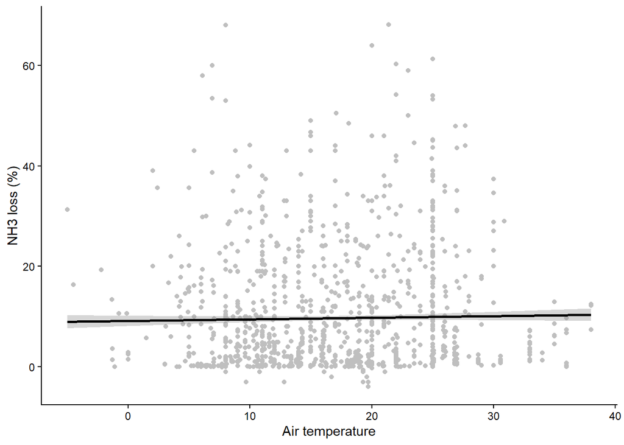

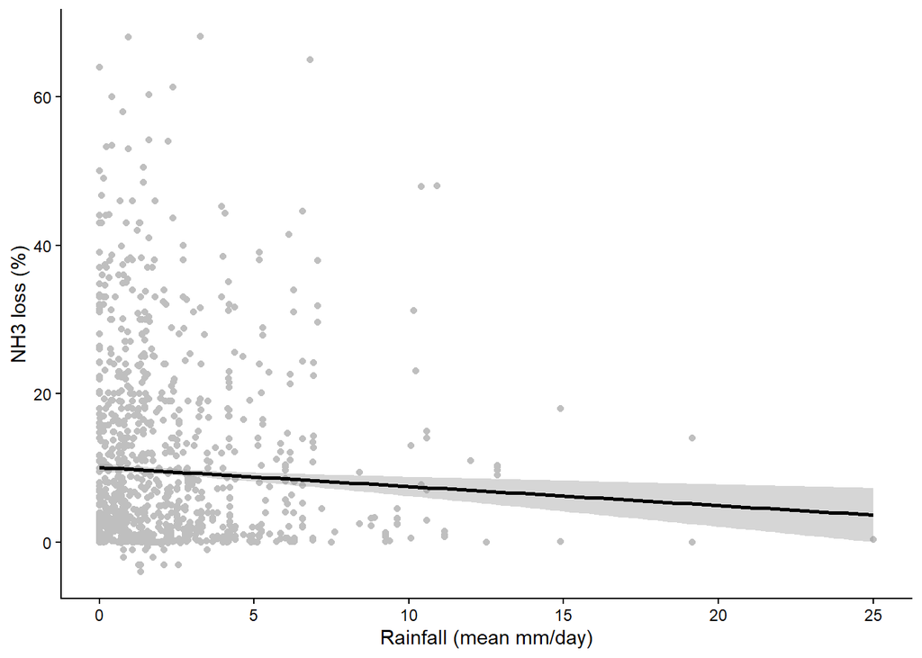

### A_Rainfall as a non-linear effect

We fitted an exponential function with parameters a and b to rainfall data. The equation is as follows:

$f(Rain.mean) = a * e^{(b*Rain.mean)}$

To test the fit and to estimate parameters a and b, we fitted a non-linear least-squares model.

```
##
## Formula: NH3loss ~ a * exp(b * (Rain.mean))
##
## Parameters:
##   Estimate Std. Error t value Pr(>|t|)
## a 11.57340    0.58608   19.75   <2e-16 ***
## b -0.03525    0.01727   -2.04   0.0416 *
## ---
## Signif. codes:  0 '***' 0.001 '**' 0.01 '*' 0.05 '.' 0.1 ' ' 1
##
## Residual standard error: 12.57 on 932 degrees of freedom
##
## Number of iterations to convergence: 12
## Achieved convergence tolerance: 1.49e-08
```

The fitted relationship is as below:

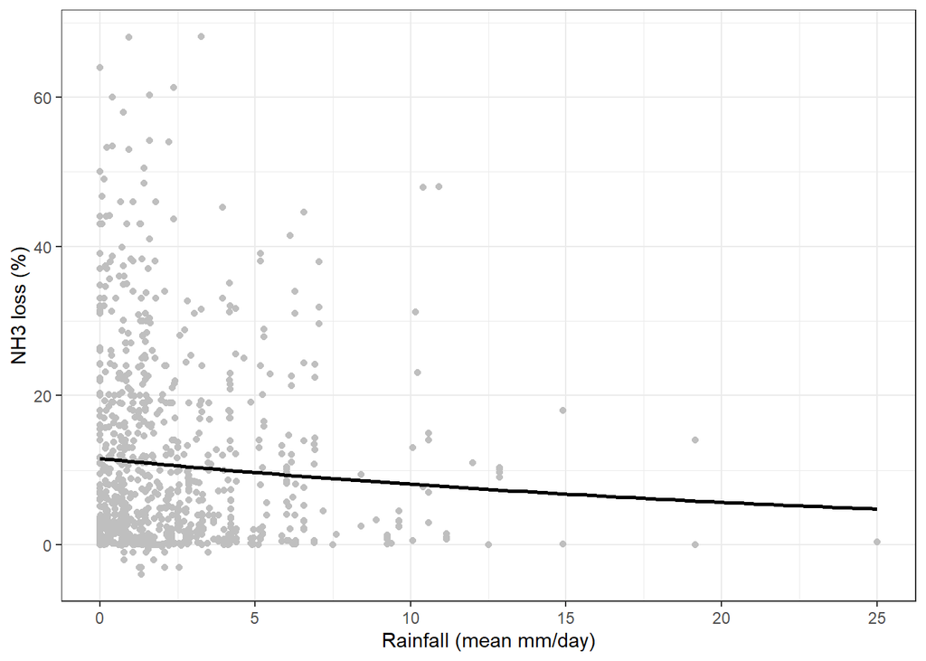

The RMSE (root mean square error) of the model was 12.5526708, which is on the same scale as mean NH3loss values in the data (10.7023381) indicating a poor fit of the model. (Error equal to the estimated value.)

We calculated new rain estimates on the exponential scale, with the estimated parameters taken into account, and ran the analysis with air temperature again, using the exponential Rain.mean values calculated using the coefficients (parameter estimates) from the non-linear least-squares fit above.

```r
# Transforming the Rain values to exp-scale
NH3predict_m7$Rain.exp <- coef(MR_nls)[[1]]*exp(coef(MR_nls)[[2]]*NH3predict_m7$Rain.mean)
```

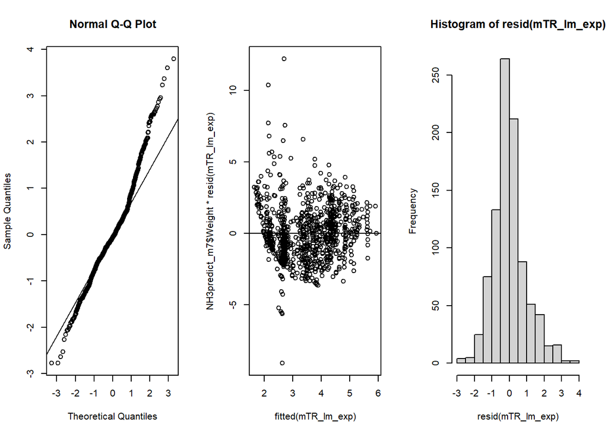

```
##
## Call:
## lm(formula = sqrt(NH3loss + 4) ~ AirTemperature * Rain.exp +
##     offset(M1_fit), data = NH3predict_m7, weights = Weight)
##
## Weighted Residuals:
##     Min      1Q  Median      3Q     Max
## -4.9013 -0.8208 -0.1029  0.7021  6.8097
##
## Coefficients:
##                          Estimate Std. Error t value Pr(>|t|)
## (Intercept)             -1.826121   1.016609  -1.796   0.0728 .
## AirTemperature           0.059100   0.044883   1.317   0.1882
## Rain.exp                 0.155501   0.092746   1.677   0.0940 .
## AirTemperature:Rain.exp -0.004694   0.004134  -1.135   0.2565
## ---
## Signif. codes:  0 '***' 0.001 '**' 0.01 '*' 0.05 '.' 0.1 ' ' 1
##
## Residual standard error: 1.265 on 930 degrees of freedom
## Multiple R-squared:  0.009131,   Adjusted R-squared:  0.005935
## F-statistic: 2.857 on 3 and 930 DF,  p-value: 0.03615
```

When the interaction is removed, we end in a model showing very similar results as the linear model above, with no statistically significant effect of rainfall (F(1, 931) =3.69, p = 0.055), nor air temperature (F(1, 931) =3.59, p = 0.058), but a statistically significant slope for air temperature (see below).

```
##
## Call:
## lm(formula = sqrt(NH3loss + 4) ~ AirTemperature + Rain.exp +
##     offset(M1_fit), data = NH3predict_m7, weights = Weight)
##
## Weighted Residuals:
##     Min      1Q  Median      3Q     Max
## -4.9123 -0.8178 -0.1093  0.7004  6.8087
##
## Coefficients:
##                 Estimate Std. Error t value Pr(>|t|)
## (Intercept)    -0.735132   0.332202  -2.213   0.0271 *
## AirTemperature  0.008287   0.003456   2.398   0.0167 *
## Rain.exp        0.055419   0.028866   1.920   0.0552 .
## ---
## Signif. codes:  0 '***' 0.001 '**' 0.01 '*' 0.05 '.' 0.1 ' ' 1
##
## Residual standard error: 1.265 on 931 degrees of freedom
## Multiple R-squared:  0.007757,   Adjusted R-squared:  0.005626
## F-statistic: 3.639 on 2 and 931 DF,  p-value: 0.02664
```

When non-linear rain is analysed separately, there is no effect of rain on NH3loss (F(1, 1036) =1.18, p = 0.278). See the slope estimate from below:

```
##
## Call:
## lm(formula = sqrt(NH3loss + 4) ~ Rain.exp + offset(M1_fit), data = NH3predict_m8,
##     weights = Weight)
##
## Weighted Residuals:
##     Min      1Q  Median      3Q     Max
## -4.8537 -0.8257 -0.1123  0.6992  6.7829
##
## Coefficients:
##             Estimate Std. Error t value Pr(>|t|)
## (Intercept) -0.30910    0.28378  -1.089    0.276
## Rain.exp     0.02877    0.02649   1.086    0.278
##
## Residual standard error: 1.261 on 1036 degrees of freedom
## Multiple R-squared:  0.001137,   Adjusted R-squared:  0.000173
## F-statistic: 1.179 on 1 and 1036 DF,  p-value: 0.2777
```